# Monte Carlo to Perform Volume Integral Over Earth; Save Interaction Locations for Flavor Dependent Weights Later

## Perform Preferential Sampling to save time on finding an accurate value

The goal of a Monte Carlo integration is to perform the integral $I = \int f( x) d x$ where $x$ is a parameter. The simplest way to accomplish this goal is to uniformly sample $x$ over the available space, and let $dx = range(x)/n_{events}$. However, if $f(x)$ spans several orders of magnitude over the range of $x$, it is more advantageous to preferentially sample the values of x that lead to larger $f(x)$. If we sample $x$ with probability distribution function of $\rho(x)$, then we perform

$I = \int f(x) \rho(x) dx^{'} \quad(1a)$

$dx^{'} = \dfrac{range(x)}{n_{events} \rho(x)} \quad (1b)$

Performing the integral in this manner will allow us to save time, provided we pick a good value for $\rho(x)$.

Initialization

```python
import matplotlib
from mpl_toolkits import mplot3d
from matplotlib import pyplot as plt
import numpy as np
from numpy import pi as pi
from matplotlib import ticker, cm
import math
import scipy as sp
from scipy import special as spc
from numpy import random as rand
from numpy import sin, cos
```

```python
alpha = 1/137 #SI Units
mn = 0.01 #Mass of lepton GeV
d = 1e-9 #Dipole coupling (MeV^-1)
Zed = 14 #Atomic number of Silicon
A_Si = 28 #Atomic mass of Silicon
R_Earth = 6378.1 * 1000* 100    #Radius of the Earth (cm)
Num_Events = int(1e6)
```

We read in the flux of neutrinos as a function of energy from a data file. We will then randomly select an energy from within this range, and use interpolation to obtain the flux. The energy spectrum roughly follows a power-law with a changing exponent, so we'll use np.interp to perfrom linear interpolation on the log-log plot

$ln(\Phi(E)) = ln(\Phi(E_a)) + [ln(\Phi(E_b))-ln(\Phi(E_a))] \dfrac{ln(E)-ln(E_a)}{ln(E_b)-ln(E_a)} \quad (2a)$

$E \in [E_a, E_b] \quad (2b)$

```python
#Read in the flux
orig_Energies = np.zeros(600)        #Neutrino Energies(GeV)
orig_initial_flux = np.zeros(len(orig_Energies))  #Neutrnio Flux (cm^-2 s^-1 GeV^-1)
#dE = Energies[1] - Energies[0]
data = open('kam-nu-01-01-000.d')
data_index = 0
for line in data:
    if data_index >= 2:
        line = line.split(' ')
        line.remove('')
        #print(line)
        orig_Energies[data_index - 2] = float(line[0])
        #divide by 100^2 to get it from m^-2 to cm^-2
        orig_initial_flux[data_index - 2] = (float(line[1])+float(line[2])+float(line[3])+float(line[4]))/(100*100)

    data_index += 1
data.close()

orig_Energies = orig_Energies[0:data_index-2]
orig_initial_flux = orig_initial_flux[0:data_index-2]
```

$\rho(E_{\nu}) = \kappa E_{\nu}^{-2} \quad;\quad \kappa = \dfrac{E_{min}E_{max}}{E_{max}-E_{min}}\quad(3)$

To get energies that fit this distribution, we will use $X \sim U[0,1]$ and find the energy $E_{\nu}$ such that

$\int_{E_{min}}^{E_{\nu}} \kappa E^{-2} dE = X \quad (4a)$

$E_{\nu} = \dfrac{\kappa E_{\min}}{\kappa - E_{\min} X} \quad(4b)$

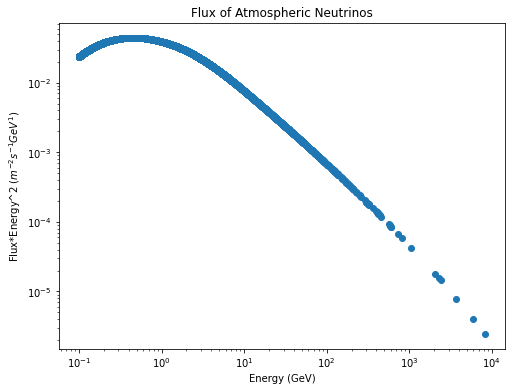

```python
#Select our energies randomly
min_E = orig_Energies[0] #GeV
max_E = orig_Energies[len(orig_Energies)-1] #GeV
kappa = (min_E*max_E)/(max_E - min_E) #GeV

Energies =(kappa*min_E)/(kappa - min_E*rand.rand(Num_Events)) #Neutrino Energies (GeV)

#Interpolate the flux on a log-log plot
ln_fluxes = np.interp(np.log(Energies), np.log(orig_Energies), np.log(orig_initial_flux))
fluxes = np.exp(ln_fluxes) #Neutrino Fluxes (m^-2 s^-1 GeV^-1)

fig = plt.figure(figsize = (8,6))
plt.scatter(Energies[0:100000],fluxes[0:100000]*Energies[0:100000]**2)
plt.xlabel('Energy (GeV)')
plt.ylabel('Flux*Energy^2 ($m^{-2} s^{-1} GeV^{1}$)')
plt.title('Flux of Atmospheric Neutrinos')
plt.xscale('log')
plt.yscale('log')
```

Fig. Scatter plot of the Flux $\times$ Energy^2 vs the Energy for incoming neutrinos. We see that the spectrum follows a slowly changing power law

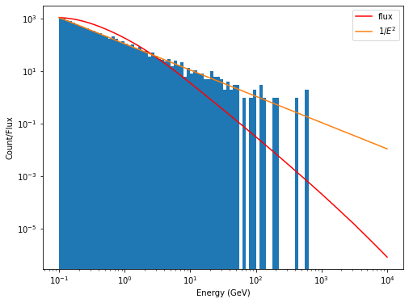

```python
fig2 = plt.figure(figsize = (8,6))

n,bins,patches = plt.hist(Energies[0:10000], orig_Energies)
plt.xscale('log')
plt.xlabel('Energy (GeV)')
plt.yscale('log')
plt.ylabel('Count/Flux')
plt.plot(orig_Energies,orig_Energies*orig_initial_flux*n[0]/(orig_initial_flux[0]*orig_Energies[0]), color = 'r',label = 'flux')
plt.plot(orig_Energies,orig_Energies*(orig_Energies[0]/orig_Energies**2)*n[0], label = '$1/E^2$')
plt.legend()
```

Fig. Histogram of the selected energies with the normalized flux overlayed. We can see that our distribution doesn't follow the flux, but has the tred of fewer events at high energy.

From the energy of the neutrino (which we assume to also be the energy of the lepton), the mass of the lepton $m_N$ and the dipole coupling strength $d$, we can determine the length of lepton decay by

$\lambda = R_{\oplus} \big[\, \dfrac{1.97 \times 10^{-9} MeV^{-1}}{d} \big]\,^2 \big[\, \dfrac{1 MeV}{m_N} \big]\,^4 \big[\, \dfrac{E_N}{10 MeV} \big]\, \sqrt{\dfrac{1-m_N^2/E_N^2}{0.99}} \quad (5)$

```python
mn_MeV = mn*1000
En_MeVs = Energies*1000
Lambdas = R_Earth * (1.97e-9/d)**2 *(1/mn_MeV)**4 * (En_MeVs/10) * np.sqrt((1-mn**2/Energies**2)/0.99) #Decay lengths (cm)
```

We would like to now sample volume elements, but do it in such a way that is favorable for the Monte Carlo. We want our events to be within $5\lambda$ of the detector (any further than this, and the probability for detection drops drastically. We also need our events to occur within the Earth. For any two overlapping spheres of radii $r_1$ and $r_2$ with their centers separated by distance $d$ ($d < r_1 + r_2$), the volume of the overlap is

$V_{overlap} = \dfrac{\pi}{12d}(r_1 + r_2 - d)^2 \big(\, d^2 + 2d(r_1+r_2) - 3(r_1-r_2)^2 \big )\, \quad(6a)$

Therefore for our case of $r_1 = R_{\oplus}$ and $r_2 = 5 \lambda$

$V_{interaction} = \dfrac{\pi}{12R_{\oplus}}(5\lambda)^2(40R_{\oplus}\lambda - 75 \lambda^2) \quad for \quad 5 \lambda < 2 R_{\oplus} \quad (6c)$

$V_{interaction} = \dfrac{4\pi R_{\oplus}^3}{3} \quad for \quad 5 \lambda \geq 2R_{\oplus}$

We will weight our results by $dV^{'} = dV ( V_{interaction}/V_{\oplus})$

To select volume elements, we'll use spherical coordinates $r^{'}, \theta^{'}, \phi^{'}$ relative to the detector, with the true position vector given by $\overrightarrow{x} = \big(\, r^{'} \sin\theta^{'} \cos\phi^{'}, r^{'} \sin\theta^{'} \sin\phi^{'}, R_{\oplus} + r^{'} \cos\theta^{'} \big )\,$. We sample these values from $\phi^{'} \sim U[0,2\pi]$, $\cos\theta^{'} \sim U[-1,0]$ (we only want angles that point toward the Earth), $r^{'} = 5 \lambda \sqrt[3]{X}$ where $X \sim U[0,1]$. (If $5\lambda > 2 R_{\oplus}$ then $r^{'} = 2 R_{\oplus} \sqrt[3]{X}$)

We then require $|\overrightarrow{x}| \leq R_{\oplus}$. If this is not the case, we sample again, and repeat this process until all of the events have been assigned a position

```python
five_lambda_over_2R = 5*Lambdas > 2*R_Earth #Find the indeces for which 5 * lambda > 2*R_Earth
interaction_radii = 5*Lambdas #Find the radius for which we will sample for interactions cm
interaction_volumes = (pi/(12*R_Earth))* (5*Lambdas)**2 * (40*R_Earth*Lambdas - 75 * Lambdas**2) #Volumes of interaction #cm^3
interaction_radii[five_lambda_over_2R] = 2*R_Earth #If 5*lambda > 2*R_Earth, then set the desired radius to 2*R_Earth
interaction_volumes[five_lambda_over_2R] = (4*pi*R_Earth**3)/3

#Go through the loop to assign positions to all of our events
'''
r_primes = np.zeros(Num_Events)
theta_primes = np.zeros(Num_Events)
phi_primes = np.zeros(Num_Events)
'''
x_vect_vals = np.zeros((Num_Events,3))
needed_indeces = x_vect_vals[:,0] < 1 #indeces for which we still need to assign positions (initially all of them)
needed_events = Num_Events #Events for which we still need to assign positions
rs_from_Earth = np.zeros(Num_Events) #distances from Earth's center

while needed_events > 0:
    #randomly calculate the point in spherical coordinates
    r_primes = interaction_radii[needed_indeces] * (rand.rand(needed_events)**(1/3))
    cos_theta_primes = -rand.rand(needed_events)
    theta_primes = np.arccos(cos_theta_primes)
    phi_primes = 2*pi*rand.rand(needed_events)

    #Find the vector from the spherical coordinate vals
    x_vect_vals[needed_indeces,0] = r_primes*sin(theta_primes)*cos(phi_primes)
    x_vect_vals[needed_indeces,1] = r_primes*sin(theta_primes)*sin(phi_primes)
    x_vect_vals[needed_indeces,2] = R_Earth + r_primes*cos(theta_primes)

    #Find if the volume element is outside the Earth
    rs_from_Earth[needed_indeces] = np.sqrt(x_vect_vals[needed_indeces,0]**2 + x_vect_vals[needed_indeces,1]**2 + x_vect_vals[needed_indeces,2]**2) #Radius relative to the center of Earth
    needed_indeces[needed_indeces] = rs_from_Earth[needed_indeces] > R_Earth #Elements outside of the Earth
    needed_events = sum(needed_indeces)
    print(needed_events)
print('done')
```

```
41347
11035
6280
4201
2938
2131
1542
1117
816
590
454
343
243
182
134
96
65
52
43
32
22
19
14
12
7
7
6
6
4
1
1
1
1
1
1
1
1
1
0
done
```

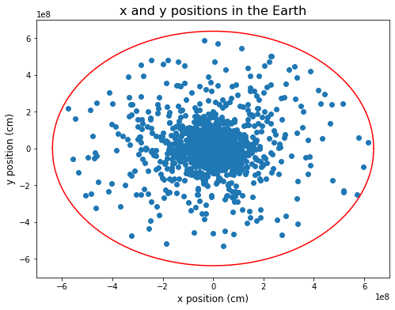

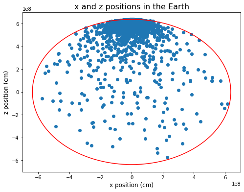

```python
x_circle_values = np.linspace(-R_Earth,R_Earth,1000)
y_pos_circle_values = np.sqrt(R_Earth**2 - x_circle_values**2)
y_neg_circle_values = -np.sqrt(R_Earth**2 - x_circle_values**2)

fig = plt.figure(figsize= (8,6))
plt.scatter(x_vect_vals[0:10000,0], x_vect_vals[0:10000,1])
plt.plot(x_circle_values,y_pos_circle_values,color = 'red')
plt.plot(x_circle_values,y_neg_circle_values,color = 'red')
plt.xlabel('x position (cm)', fontsize = 12)
plt.ylabel('y position (cm)', fontsize = 12)
plt.title('x and y positions in the Earth',fontsize = 16)

fig2 = plt.figure(figsize = (8,6))
plt.scatter(x_vect_vals[0:10000,0], x_vect_vals[0:10000,2])
plt.plot(x_circle_values,y_pos_circle_values,color = 'red')
plt.plot(x_circle_values,y_neg_circle_values,color = 'red')
plt.xlabel('x position (cm)', fontsize = 12)
plt.ylabel('z position (cm)', fontsize = 12)
plt.title('x and z positions in the Earth', fontsize = 16)
```

Figs. Distribution of volume elements in the Earth. We see that most of the events are clustered around the detector, since most of our neutrinos have sub-GeV to a couple GeV energies, and therefore have small decay lengths.

We now wish to calculate $\dfrac{d\sigma}{d\cos{\beta}}$, where $\beta$ is the scattering angle, which will be used in the probability to scatter. We have a function for $\dfrac{d\sigma}{dt}$ where $t = -q^2$ and $q$ is the transferred momentum. We will work in the infinite mass limit, so the energy transfered to the nucleus is zero, and $E_N = E_{\nu}$. Therefore, we have

$t = -(\overrightarrow{p_{\nu}} - \overrightarrow{p_{N}})^2 = E_{\nu}^2+p_N^2-2E_{\nu}p_N \cos\beta \quad (9)$

Where we know

$p_N = \sqrt{E_N^2-m_N^2} = \sqrt{E_{\nu}^2-m_N^2} \quad(10)$

$t = 2E_{\nu}^2 - m_N^2 - 2 E_{\nu}\sqrt{E_{\nu}^2-m_N^2} \cos\beta \quad(11a)$

$dt = -2 E_{\nu} \sqrt{E_{\nu}^2 - m_N^2} d(\cos\beta) \quad (11b)$

We can now sub this into our differential cross section

$\dfrac{d\sigma}{dt} = \dfrac{Z^2 d^2 \alpha}{t E_{\nu}^2} (4E^2_{\nu} -m^2_{N}+\dfrac{m^4_N}{t}) \quad (12a)$

$\dfrac{d\sigma}{d(-2E_{\nu}\sqrt{E_{\nu}^2 - m_N^2}\cos\beta)} = \dfrac{Z^2 d^2 \alpha}{t E_{\nu}^2} (4E^2_{\nu} -m^2_{N}+\dfrac{m^4_N}{t}) \quad (12b)$

$\dfrac{d\sigma}{d(\cos\beta)} = \dfrac{-2\sqrt{E_{\nu}^2-m_N^2}*Z^2 d^2 \alpha}{E_{\nu}t} (4E^2_{\nu} -m^2_{N}+\dfrac{m^4_N}{t}) \quad (12c)$

$\dfrac{d\sigma}{d(\cos\beta)} = \dfrac{-2\sqrt{E_{\nu}^2-m_N^2}*Z^2 d^2 \alpha}{E_{\nu} (2E_{\nu}^2 - m_N^2 - 2 E_{\nu}\sqrt{E_{\nu}^2-m_N^2} \cos\beta)} (4E^2_{\nu} -m^2_{N}+\dfrac{m^4_N}{2E_{\nu}^2 - m_N^2 - 2 E_{\nu}\sqrt{E_{\nu}^2-m_N^2} \cos\beta}) \quad (12d)$

This returns a negative answer, so we flip the sign

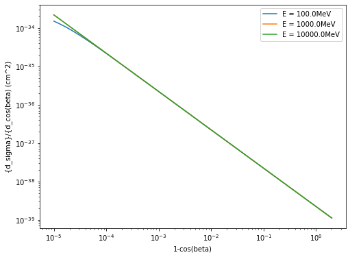

```python
fig = plt.figure(figsize = (8,6))
plot_cos_betas = 1-np.logspace(-5,np.log10(2),500)
trial_Energies = np.logspace(2,4,3) #Neutrino Energy (MeV)
for trial_E in trial_Energies:
    ts = 2*trial_E**2 - mn_MeV**2 - 2*trial_E*np.sqrt(trial_E**2 - mn_MeV**2) * plot_cos_betas #Transfere momentum^2 (MeV^2)
    leading_terms = (-2* np.sqrt(trial_E**2 - mn_MeV**2) * Zed**2*d**2*alpha)/(trial_E*ts) #MeV^-4
    second_terms = (4*trial_E**2 - mn_MeV**2 + mn_MeV**4/ts) #MeV^2
    Inv_Mev_to_cm = (197.3) * 1e-13 #MeV^-1 to fm * fm to cm
    plot_ds_dcos = Inv_Mev_to_cm**2 * -leading_terms*second_terms #cm^2
    plt.plot(1-plot_cos_betas,plot_ds_dcos,label = "E = "+str(trial_E)+"MeV")
plt.xscale('log')
plt.yscale('log')
plt.xlabel("1-cos(beta)")
plt.ylabel("{d_sigma}/{d_cos(beta) (cm^2)")
plt.legend()
```

Fig. Differential cross section as a function of $\cos\beta$. The cross section becomes orders of magnitude greater when $\cos\beta$ approaches 1.

The flux of incoming neutrinos is isotropic, so the true distibution of scattering angles $\beta$ follows $\cos\beta \sim U[-1,1]$. Since the value of $\dfrac{d\sigma}{d\cos\beta}$ become orders of magnitude larger for a small range of $\cos\beta$ it makes sense to only sample where the cross section is large. We can see that the differential cross section roughly follows $\dfrac{1}{1-\cos\beta}$. For right now, we'll define $A = 1-\cos\beta$ and let

$\rho(A) = \dfrac{\epsilon}{A} \quad ; \quad \epsilon = \dfrac{1}{\ln(A_{max}/A_{min})} \quad (13)$

$\int_{A_{min}}^{A} \dfrac{\epsilon}{A^{'}} dA^{'} = X \quad (14a)$

$A = (A_{min})^{1-X} (A_{max})^{X} \quad (14b)$

$\cos\beta = 1 - (A_{min})^{1-X} (A_{max})^{X} \quad (14c)$

```python
X = rand.rand(Num_Events)
A_min = 1e-8
A_max = 2
cos_betas = 1 - (A_min)**(1-X) * (A_max)**X
betas = np.arccos(cos_betas)
```

Now, we will $\psi \sim U[0,2\pi]$. We will use $\psi$ and $\beta$ to define $\overrightarrow{v_{in}}$ which is the path by which the neutrino entered Earth. This is will become important when considering matter effects for neutrino oscillations.

$\hat{v_{in}} = \hat{v_{out}}\cos\beta + \hat{v_{\perp1}}\sin\beta\cos\psi + \hat{v_{\perp2}}\sin\beta\sin\psi \quad (15)$

Where $\hat{v_{out}}$,$\hat{v_{\perp1}}$, and $\hat{v_{\perp2}}$ are all mutually orthogonal. Initial definition of the two new vectors is arbitrary, so we shall let

$\dfrac{\overrightarrow{x} \times \overrightarrow{v_{out}}}{|\overrightarrow{x} \times \overrightarrow{v_{out}}|} = \hat{v_{\perp1}} \quad (16a)$

$\hat{v_{out}} \times \hat{v_{\perp1}} = \hat{v_{\perp2}} \quad(16b)$

Where $\overrightarrow{v_{out}}$ is the vector that points from the volume element to the detector. It is given by $\overrightarrow{v_{out}} = (-x, -y, R_{\oplus} - z)$ where $x$, $y$, and $z$ are the Cartesian coordinates of the volume element

```python
#Calculate the v_out vector
v_outs = np.zeros((Num_Events,3))
v_outs[:,0],v_outs[:,1],v_outs[:,2] = -x_vect_vals[:,0], -x_vect_vals[:,1], R_Earth - x_vect_vals[:,2]

#Calculate the magnitude of v_out
v_out_mags = np.sqrt(v_outs[:,0]**2 + v_outs[:,1]**2 + v_outs[:,2]**2)

#Initialize the perpendicular unit vectors
v_perp_1_hats = np.zeros((Num_Events,3))
v_perp_2_hats = np.zeros((Num_Events,3))
#Caluclate the cross product of x and v_out
x_vect_cross_v_out = np.zeros((Num_Events,3))
x_vect_cross_v_out[:,0] = x_vect_vals[:,1]*v_outs[:,2] - x_vect_vals[:,2]*v_outs[:,1]
x_vect_cross_v_out[:,1] = x_vect_vals[:,2]*v_outs[:,0] - x_vect_vals[:,0]*v_outs[:,2]
x_vect_cross_v_out[:,2] = x_vect_vals[:,0]*v_outs[:,1] - x_vect_vals[:,1]*v_outs[:,0]
x_cross_v_mag = np.sqrt(x_vect_cross_v_out[:,0]**2 + x_vect_cross_v_out[:,1]**2 + x_vect_cross_v_out[:,2]**2)

v_perp_1_hats[:,0] = x_vect_cross_v_out[:,0]/x_cross_v_mag
v_perp_1_hats[:,1] = x_vect_cross_v_out[:,1]/x_cross_v_mag
v_perp_1_hats[:,2] = x_vect_cross_v_out[:,2]/x_cross_v_mag

#Calculate the second perpendicular component
v_perp_2_hats[:,0] = (v_outs[:,1]*v_perp_1_hats[:,2] - v_outs[:,2]*v_perp_1_hats[:,1])/v_out_mags
v_perp_2_hats[:,1] = (v_outs[:,2]*v_perp_1_hats[:,0] - v_outs[:,0]*v_perp_1_hats[:,2])/v_out_mags
v_perp_2_hats[:,2] = (v_outs[:,0]*v_perp_1_hats[:,1] - v_outs[:,1]*v_perp_1_hats[:,0])/v_out_mags

#Calculate v_out_hat
v_out_hats = np.zeros((Num_Events,3))
v_out_hats[:,0],v_out_hats[:,1],v_out_hats[:,2] = v_outs[:,0]/v_out_mags, v_outs[:,1]/v_out_mags, v_outs[:,2]/v_out_mags

#Randomly select a psi, and return out v_in vectors
psis = 2*pi*rand.rand(Num_Events)
v_in_hats = np.zeros((Num_Events,3))
v_in_hats[:,0] = v_out_hats[:,0]*cos(betas) + v_perp_1_hats[:,0]*sin(betas)*cos(psis) + v_perp_2_hats[:,0]*sin(betas)*sin(psis)
v_in_hats[:,1] = v_out_hats[:,1]*cos(betas) + v_perp_1_hats[:,1]*sin(betas)*cos(psis) + v_perp_2_hats[:,1]*sin(betas)*sin(psis)
v_in_hats[:,2] = v_out_hats[:,2]*cos(betas) + v_perp_1_hats[:,2]*sin(betas)*cos(psis) + v_perp_2_hats[:,2]*sin(betas)*sin(psis)
```

```python
#Find the differential cross section with respect to the angle beta
En_MeVs = Energies *1000  #Neutrino/Lepton Energies in MeV
mn_MeV = mn*1000  #Lepton mass in MeV
ts = 2*En_MeVs**2 - mn_MeV**2 - 2*En_MeVs*np.sqrt(En_MeVs**2 - mn_MeV**2) * cos_betas #Transfere momentum^2 (MeV^2)

leading_terms = (-2* np.sqrt(En_MeVs**2 - mn_MeV**2) * Zed**2*d**2*alpha)/(En_MeVs*ts) #MeV^-4
second_terms = (4*En_MeVs**2 - mn_MeV**2 + mn_MeV**4/ts) #MeV^2
Inv_Mev_to_cm = (197.3) * 1e-13 #MeV^-1 to fm * fm to cm
d_sigmas_d_cos_beta = Inv_Mev_to_cm**2 * -leading_terms*second_terms #cm^2

print('d sigma/d cos(beta)', d_sigmas_d_cos_beta[100:110],'cm^2')
```

```
d sigma/d cos(beta) [5.35580416e-34 2.33962233e-36 6.78553956e-38 1.21917147e-32
 1.47755727e-33 2.70485589e-39 3.38038933e-36 1.36851937e-33
 4.61978208e-33 2.52454359e-37] cm^2
```

We have already determined the decay length from Eq 5. We know that the probability for the lepton to decay and produce a photon in our detector of lenght $l_{dec}$ is

$P_{dec}(\overrightarrow{v_{out}},\lambda) = \exp \big(\, \dfrac{-|\overrightarrow{v_{out}}|}{\lambda} \big)\, \bigg(\, 1-\exp \big(\, \dfrac{-l_{dec}}{\lambda} \big)\, \bigg)\, \quad (17)$

```python
l_dec = 10*100 #length of the detector in cm
P_decs = np.exp(-v_out_mags/Lambdas) * (1-np.exp(-l_dec/Lambdas))
print('Prob of decay',P_decs[100:105])
```

```
Prob of decay [5.47289685e-06 1.24709060e-05 3.26021209e-07 1.99136061e-05
 3.37618849e-06]
```

We also need $n(\overrightarrow{x})$, which is the number density of nuclei at our volume element. We claim density is purely a function of radius r out from the center of the Earth, and that it linearly decreases as the radius increases. Setting the density of the surface to 3 $g/cm^3$ and the density at the core to 13 $g/cm^3$ gives us a mass similar to that of the Earth

```python
def Earth_Density(r, R_Earth):
    core_density = 13 #g/cm^3
    surface_density = 3 #g/cm^3

    dens = core_density + (surface_density - core_density) * (r/R_Earth)
    return(dens)
```

```python
rs = np.sqrt(x_vect_vals[:,0]**2 + x_vect_vals[:,1]**2 + x_vect_vals[:,2]**2)
densities = Earth_Density(rs, R_Earth) #g/cm^3
num_densities = (densities/A_Si) * 6.022e23 #nuclei/cm^3
```

The contribution to our total rate of decays is

$dR = A_{\perp}\dfrac{d\sigma}{d\cos\beta} n(\overrightarrow{x})\Phi(E_{\nu}) \dfrac{P_{dec}(\overrightarrow{v_{out}},\lambda)}{4\pi |\overrightarrow{v_{out}}|^2} dV dE_{\nu} d\cos\beta \quad (18a)$

$dV = \dfrac{\dfrac{4}{3}\pi R_{\oplus}^3}{\sqrt[3]{n_{events}}} \quad ; \quad dE_{\nu} = \dfrac{E_{max}-E_{min}}{\sqrt[3]{n_{events}}} \quad ; \quad d\cos\beta = \dfrac{2}{\sqrt[3]{n_{events}}} \quad (18b) $

For uniformly sampled values. Since we did preferential sampling, we will have to replace $dV$, $dE_{\nu}$, and $d\cos\beta$ with $dV^{'}$, $dE_{\nu}^{'}$, $d\cos\beta^{'}$. For the variable where we just restrict the parameter spaces ($dV^{'}$) it is relatively simple

$dV^{'} = \dfrac{V_{interaction}}{\sqrt[3]{n_{events}}} \quad(19) $

For the parameters we sampled from a power law, we want

$dE_{\nu}^{'} = \dfrac{E_{max}-E_{min}}{\sqrt[3]{n_{events}}} \bigg (\, \dfrac{E_{\nu}}{E_{char}} \bigg )\, ^2 \quad d\cos\beta^{'} = \dfrac{2}{\sqrt[3]{n_{events}}} \dfrac{A}{A_{char}} \quad (20)$

Where $A = 1-\cos\beta$. To find this characteristic energy and angle, we want to find where $\rho(E_{\nu}) = \dfrac{1}{E_{max}-E_{min}}$, $\rho(A) = 1/2$ where $\rho(E_{\nu})$ is from Eq 3 and the RHS of the equations are the uniform probability distributions

$E_{char} = \sqrt{E_{min}E_{max}} \quad A_{char} = \dfrac{A_{max}-A_{min}}{ln(A_{max}/A_{min})} \quad (21)$

We now have all the information needed to calculate the rate

```python
#New differential for volume
dVs = interaction_volumes/(Num_Events)**(1/3)  #Differential Volume (cm^3)

#New differential for energy
char_Energy = np.sqrt(min_E*max_E)   #Characteristic Energy (GeV)
dEs = ((max_E- min_E)/Num_Events**(1/3)) * (Energies/char_Energy)**2 #Differential energies (GeV)

#New differential for cos(beta)
A_char = (A_max - A_min)/np.log(A_max/A_min)
d_cos_betas = (2/Num_Events**(1/3))*((1-cos_betas)/A_char)
A_perp = (10 * 100)**2 #Area in cm^2

dRs = A_perp * d_sigmas_d_cos_beta * num_densities * fluxes * (P_decs/(4*pi*v_out_mags**2)) * dVs * dEs * d_cos_betas
R = sum(dRs)

print('Rate = ', R, 'decays / s')
```

```
Rate =  4.0186643127165613e-07 decays / s
```

```python
#Calculate Events per 12 years
print('M_N', mn,'GeV')
print('d', d, 'MeV^-1')
print('Events in 12 years', R*86400*365*12)
```

```
M_N 0.01 GeV
d 1e-09 MeV^-1
Events in 12 years 152.07911731899537
```

## Saving 1D Density Profiles for re-weighting

If we want to consider flavor dependence, we will need to calculate the density profile that the neutrino passed through to reach the volume element and apply flavor oscillations to that. For now, we are considering a single element and a density that solely depends on radius

$|\overrightarrow{x} - \overrightarrow{v_{in}}|^2 = R_{\oplus}^2 \quad (22a)$

$|\overrightarrow{x}|^2 - 2 \overrightarrow{x} \cdot \hat{v_{in}} |\overrightarrow{v_{in}}| + |\overrightarrow{v_{in}}|^2 = R_{\oplus}^2 \quad (22b)$

Using the quadratic formula, we know that

Since $R_{\oplus} \geq |\overrightarrow{x}|$, the value in the square root will always be greater than the first term. Since magnitude is strickly positive, we will take the plus sign. Using the unit vector and the magnitude, we can now calculate $\overrightarrow{v_{in}}$. From this, we know that the path traveled is

$\overrightarrow{r_{\nu}(u)} = \overrightarrow{x} + (u-1)\overrightarrow{v_{in}} \quad;\quad u \in [0,1] \quad (24)$

And the distance traversed by the neutrino at any value of u is $d = u |\overrightarrow{v_{in}}|$. The distance from the neutrino to the center of the Earth can be found by

$|\overrightarrow{r_{\nu}(u)}|^2 = |\overrightarrow{x}|^2 + (u-1)^2 |\overrightarrow{v_{in}}|^2 + 2 (u-1) \overrightarrow{x} \cdot \overrightarrow{v_{in}} \quad (25)$

We can then plug this into our function for the density

```python
def One_D_Density_Profile(x_vect_vals, v_in_hats, R_Earth):
    '''
    This function takes in vector for the volume element
    and the unit vector for the incoming neutrino and returns
    the corresponding density profiles

    The inputs for the vectors must be 2D arrays with
    the first index refering the event number and the second
    index refering to the cartesian dimension

    This returns the distances and densities as 2D arrays
    with the first index refering to event number and the
    second index refering to the path
    '''

    #Find the dot product of the two vectors
    x_dot_vhat = x_vect_vals[:,0]*v_in_hats[:,0] + x_vect_vals[:,1]*v_in_hats[:,1] + x_vect_vals[:,2]*v_in_hats[:,2]
    x_mag = np.sqrt(x_vect_vals[:,0]*x_vect_vals[:,0] + x_vect_vals[:,1]*x_vect_vals[:,1] + x_vect_vals[:,2]*x_vect_vals[:,2])
    #print('x*v', x_dot_vhat)

    #Find the magnitude of vin
    vin_mag = x_dot_vhat + np.sqrt(x_dot_vhat**2 -(x_mag**2 - R_Earth**2))
    #print('vin mag/R_E', vin_mag/R_Earth)

    #Determine the distances and densities
    u_vals = np.linspace(0,1,10000)
    distances = np.zeros((len(vin_mag),len(u_vals)))
    densities = np.zeros((len(vin_mag),len(u_vals)))
    u_index = 0
    for u in u_vals:
        distances[:,u_index] = vin_mag*u
        r_2 = x_mag**2 + (u-1)**2 *vin_mag**2 + 2 *(u-1) * x_dot_vhat* vin_mag  #cm^2
        rad = np.sqrt(r_2) #cm
        #print(r/R_Earth)
        densities[:,u_index] = Earth_Density(rad, R_Earth)
        u_index += 1
    return(distances,densities)
```

```python
distances,densities = One_D_Density_Profile(x_vect_vals[0:10000],v_in_hats[0:10000], R_Earth)
```

A problem which arises here is a limited memory. It takes approximately 10 seconds to find the density profiles for 10,000 events, and the returned values are 2D arrays. The fuction can not have 100,000 events as an input. This might be salvaged if we can afford a coarser density profile

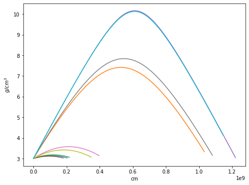

```python
fig = plt.figure(figsize = (8,6))
for i in range(10):
    plt.plot(distances[i,:],densities[i,:])
    plt.xlabel('cm')
    plt.ylabel('$g/cm^3$')
```

Fig. Density profiles for 10 neutrinos passing through the Earth

## Determining the zenith angle of the neutrino's entry

This code uses an isotropic flux of neutrinos. However, the true flux of neutrinos depends upon the zenith angle of the neutrino's entry (the angle is defined so $\phi_{zenith} = 0$ corresponds to a neutrino entering normal to Earth's surface

We will call the position of entry $\overrightarrow{r_{entry}}$ and define it as

$\overrightarrow{r_{entry}} = \overrightarrow{x} - \overrightarrow{v_{in}} \quad (26)$

We can find the zenith angle by

$\cos\phi_{zenith} = \hat{r_{entry}} \cdot \hat{v_{in}} = \dfrac{(\overrightarrow{x}-\overrightarrow{v_{in}}) \cdot (-\hat{v_{in}})}{|\overrightarrow{r_{entry}}|} = \dfrac{|\overrightarrow{v_{in}}| - \overrightarrow{x}\cdot \hat{v_{in}}}{R_{\oplus}} \quad (27)$

```python
def Zenith_Angles(x_vect_vals, v_in_hats, R_Earth):
    '''
    This function takes in the 2D arrays for position and
    incoming neutrino direction unit vectors.  The first index
    corresponds to the event number, while the second index
    correpsonds to the cartesian coordiante.
    The function also reads in a float for the radius of the Earth.
    This returns a 1D arraw of zenith angles'''
    #Find the dot product of the two vectors
    x_dot_vhat = x_vect_vals[:,0]*v_in_hats[:,0] + x_vect_vals[:,1]*v_in_hats[:,1] + x_vect_vals[:,2]*v_in_hats[:,2]
    x_mag = np.sqrt(x_vect_vals[:,0]*x_vect_vals[:,0] + x_vect_vals[:,1]*x_vect_vals[:,1] + x_vect_vals[:,2]*x_vect_vals[:,2])
    #print('x*v', x_dot_vhat)

    #Find the magnitude of vin
    vin_mag = x_dot_vhat + np.sqrt(x_dot_vhat**2 -(x_mag**2 - R_Earth**2))

    cos_zeniths = (vin_mag - x_dot_vhat)/R_Earth
    zeniths = np.arccos(cos_zeniths)
    return(zeniths)
```

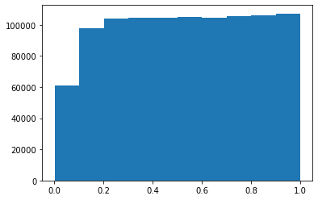

```python
zeniths = Zenith_Angles(x_vect_vals,v_in_hats,R_Earth)
plt.hist(cos(zeniths))
```

## See how flux and cross section change with energy

To study important effects, we want an idea for the value of $\Phi \times \sigma$. We'll calculate $\sigma$ in the same way as the Plestid (2020) paper

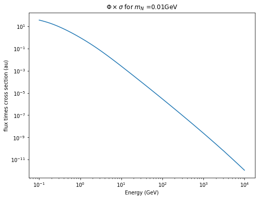

```python
#We will use the original energies to calculate this
fig = plt.figure(figsize = (8,6))
mn = .01
Q_min_2 = (orig_Energies - np.sqrt(orig_Energies**2 -mn**2))**2 #GeV^2
Q_max_2 = 2*orig_Energies**2 - mn**2 #GeV^2
sigmas = np.log(Q_max_2/Q_min_2) + mn**4/(orig_Energies**2 * Q_min_2) - 0.25* (mn/orig_Energies)**2*np.log(Q_max_2/Q_min_2) -0.25*mn**4/(orig_Energies**2 * Q_max_2)
sigmas = sigmas*np.heaviside(orig_Energies,mn)
plt.plot(orig_Energies, sigmas*orig_initial_flux)
plt.title('$\Phi \\times \sigma$ for $m_N$ ='+str(mn)+'GeV')
plt.xlabel('Energy (GeV)')
plt.ylabel('flux times cross section (au)')
plt.xscale('log')
plt.yscale('log')
```

[output not shown]